# Project: FBI NICS Guns Check

#### 'White alone, not Hispanic or Latino, percent, July 1, 2016, (V2016)' column can be considered to be the most positively correlated to guns per capita

Finding the best fit line using `numpy polyfit` function

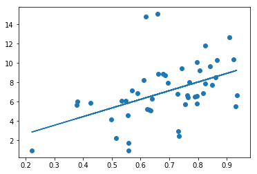

```python
x = np.array(df_merge.white_not_others_per)
y = np.array(df_merge.guns_per_thousand)
plt.scatter(x,y)
m, b = np.polyfit(x, y, 1)
plt.plot(x, m*x + b);
```

### Research Question 7: What is the distribution of the total registerations of guns?

We can explore the distribution of total guns registeration for every month.

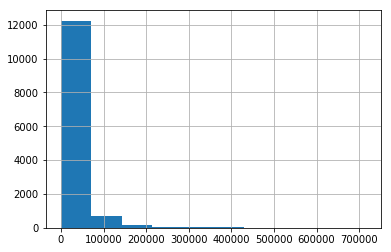

```python
guns.totals.hist();
```

It is clear that in the majority of months the registeration did not exceed 100,000.

[figure not shown]

```python
labels = 'Guns Registeration less 100,000', 'Guns Registeration more than 100,000'
high = guns.totals >=100000
low = guns.totals < 100000
sizes = [guns[high].totals.sum(), guns[low].totals.sum()]
explode = (0.1, 0)  # only "explode" the 2nd slice (i.e. 'Hogs')

fig1, ax1 = plt.subplots()
ax1.pie(sizes, explode=explode, labels=labels, autopct='%1.1f%%',
        shadow=True, startangle=90)
ax1.axis('equal')  # Equal aspect ratio ensures that pie is drawn as a circle.

plt.show()
```

## Conclusions

[figure not shown]

**From the above discussion we can conclude the followings:**

- Trend of `gun registration` shows some positive correlation with some `life threatening events` in state Louisiana and Texas (2005-2006 during `hurricane Katrina` and 2012 `The Sandy Hook school shooting`  
  as discussed in Q5 and also seen in 9/11 event.
- There is a positive correlation between the percent of `White population percent` in a state and the `registered guns per capita` in this state based upon statistics 2016  
  as discussed in Q6
- In the majority of months, the registeration did not exceed 100,000. as discussed in Q7

**Notes:**(Resubmission Note)  
The above conclusions were limited by the followings:

1. Guns registration data file:
   - We can't be certain that the number of guns registered is the same as the ones sold as per Harvard study **_[here](https://github.com/BuzzFeedNews/nics-firearm-background-checks/blob/master/README.md)** .

     > A forthcoming study conducted by Harvard researchers found that roughly **40 percent** of respondents had acquired their most recent firearm **without** going through a background check.
   - The Data file contained information about 55 states(with non-official 5 states) . I omitted those data to match `census` dataframe.
1. Census Data:
   - **Only year 2016** was analysed. This is because it was the year that only carried some complete data about the race's percentage. Further investigation of other years and going through some other important factors like non-employment, income per capita, persons per square feet could make the conclusions more precise.
   - All footnotes were eliminated to get numerical data.
   - Data file was not consistent about expressing the percentage, sometimes with the symbol `%` and sometimes with decimal point. This was overcomed by data manipulation but it can affect the accuracy of the data.

```python
from subprocess import call
call(['python', '-m', 'nbconvert', 'Investigate_a_Dataset.ipynb'])
```

```
0
```